# CS01: Right-To-Carry

To better visualize this difference, we can model it using a plot where we the estimation for each df is plotted with error bars indicating 95% confidence interval:

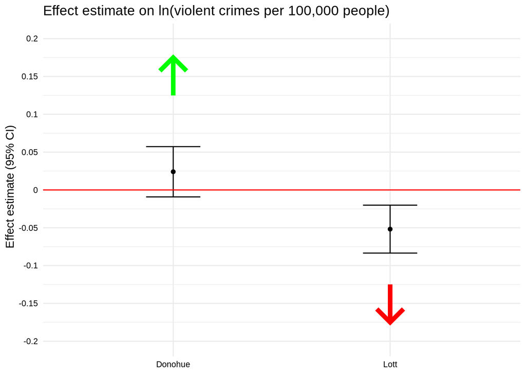

```r
ggplot(comparing_analyses) +
  geom_point(aes(x = Analysis, y = estimate)) +
  geom_errorbar(aes(x = Analysis, ymin = conf.low, ymax = conf.high), width = 0.25) +
  geom_hline(yintercept = 0, color = "red") +
  scale_y_continuous(
    breaks = seq(-0.2, 0.2, by = 0.05),
    labels = seq(-0.2, 0.2, by = 0.05),
    limits = c(-0.2, 0.2)
  ) +
  geom_segment(aes(x = 1, y = 0.125, xend = 1, yend = 0.175),
    arrow = arrow(angle = 45, ends = "last", type = "open"),
    size = 2, color = "green", lineend = "butt", linejoin = "mitre"
  ) +
  geom_segment(aes(x = 2, y = -0.125, xend = 2, yend = -0.175),
    arrow = arrow(angle = 45, ends = "last", type = "open"),
    size = 2, color = "red", lineend = "butt", linejoin = "mitre"
  ) +
  theme_minimal() +
  theme(
    axis.title.x = element_blank(),
    axis.text = element_text(size = 8, color = "black")
  ) +
  labs(
    title = "Effect estimate on ln(violent crimes per 100,000 people)",
    y = "  Effect estimate (95% CI)"
  )
```

Next, we study the effect of multicollinearity on coefficient estimates from linear regression models when analyzing this relationship which focuses on the relative association within the independent variables selected.

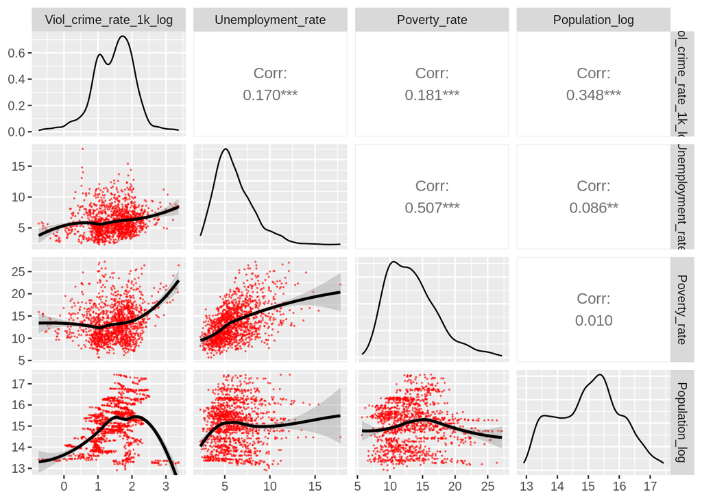

```r
DONOHUE_DF |>
  select(RTC_LAW,
         Viol_crime_rate_1k_log,
         Unemployment_rate,
         Poverty_rate,
         Population_log) |>
  ggpairs(columns = c(2:5),
          lower = list(continuous = wrap("smooth_loess",
                                         color = "red",
                                         alpha = 0.5,
                                         size = 0.1)))
```

We use heatmap modelling helps identify correlations. In this case, we observed a potential association between race and violent crime rate in previous analysis. Thus, we plot a heatmap of demographic variable to further explore.

here we are Plotting heat map based on race demographic for Donohue DF:

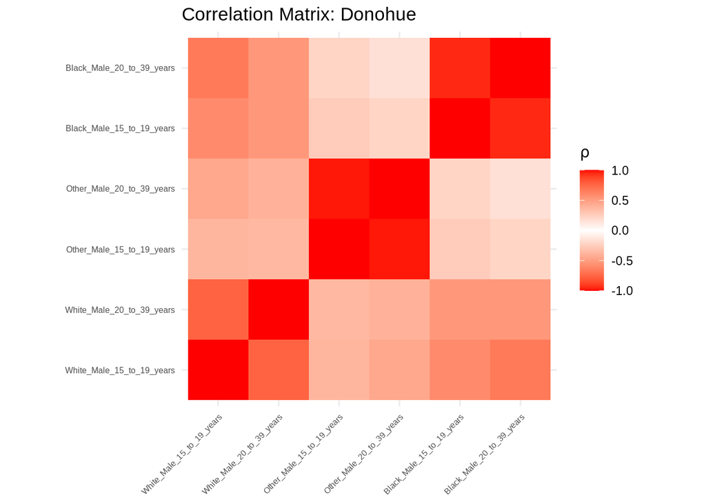

```r
cor_DONOHUE_dem <- cor(DONOHUE_DF |> select(contains("_years")))
ggcorrplot(cor_DONOHUE_dem,
  tl.cex = 6,
  hc.order = TRUE,
  colors = c(
    "red",
    "white",
    "red"
  ),
  outline.color = "transparent",
  title = "Correlation Matrix: Donohue",
  legend.title = expression(rho)
)
```

Also plotting heat map based on race demographic for Lott DF:

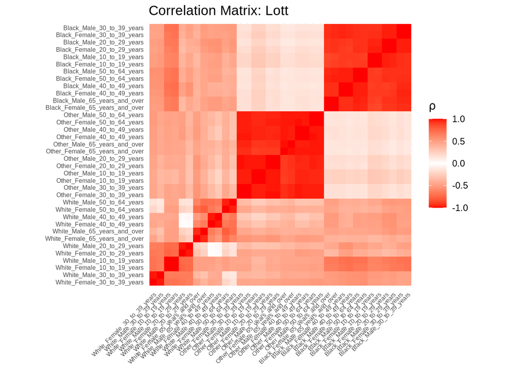

```r
cor_LOTT_dem <- cor(LOTT_DF |> select(contains("_years")))
corr_mat_LOTT <- ggcorrplot(cor_LOTT_dem,
  tl.cex = 6,
  hc.order = TRUE,
  colors = c(
    "red",
    "white",
    "red"
  ),
  outline.color = "transparent",
  title = "Correlation Matrix: Lott",
  legend.title = expression(rho)
)
corr_mat_LOTT
```

According to these plots, we see a strong correlation between race as opposed to age. Thus, we can further investigate whether the race factor could have a collinearity.

Now, we need to make sure of this collinearity. Here we are perform leave-one-out cross-validation on panel data.

```r
## split data
set.seed(124)
DONOHUE_splits <- d_panel_DONOHUE |> loo_cv()
DONOHUE_splits
```

```
## # Leave-one-out cross-validation
## # A tibble: 1,364 × 2
##    splits           id
##    <list>           <chr>
##  1 <split [1363/1]> Resample1
##  2 <split [1363/1]> Resample2
##  3 <split [1363/1]> Resample3
##  4 <split [1363/1]> Resample4
##  5 <split [1363/1]> Resample5
##  6 <split [1363/1]> Resample6
##  7 <split [1363/1]> Resample7
##  8 <split [1363/1]> Resample8
##  9 <split [1363/1]> Resample9
## 10 <split [1363/1]> Resample10
## # … with 1,354 more rows
```

```r
DONOHUE_subsets <- map(pull(DONOHUE_splits, splits), training)
glimpse(DONOHUE_subsets[[1]])
```

```
## Rows: 1,363
## Columns: 20
## $ YEAR                      <fct> 1980, 1981, 1982, 1983, 1984, 1985, 1986, 19…
## $ STATE                     <fct> Alaska, Alaska, Alaska, Alaska, Alaska, Alas…
## $ Black_Male_15_to_19_years <pseries> 0.1670456, 0.1732299, 0.1737069, 0.17095…
## $ Black_Male_20_to_39_years <pseries> 0.9933775, 1.0028219, 1.0204445, 1.03127…
## $ Other_Male_15_to_19_years <pseries> 1.1297816, 1.1244412, 1.0698208, 0.98828…
## $ Other_Male_20_to_39_years <pseries> 2.963329, 2.974775, 3.015071, 3.008048, …
## $ White_Male_15_to_19_years <pseries> 3.627805, 3.558261, 3.391844, 3.222002, …
## $ White_Male_20_to_39_years <pseries> 18.28852, 18.12821, 18.10666, 17.90600, …
## $ Unemployment_rate         <pseries> 9.6, 9.4, 9.9, 9.9, 9.8, 9.7, 10.9, 10.3…
## $ Poverty_rate              <pseries> 9.6, 9.0, 10.6, 12.6, 9.6, 8.7, 11.4, 12…
## $ Viol_crime_count          <pseries> 1919, 2537, 2732, 2940, 3108, 3031, 3046…
## $ Population                <pseries> 404680, 418519, 449608, 488423, 513697, …
## $ police_per_100k_lag       <pseries> 194.7218, 200.2299, 191.0553, 364.2335, …
## $ RTC_LAW_YEAR              <pseries> 1995, 1995, 1995, 1995, 1995, 1995, 1995…
## $ RTC_LAW                   <pseries> FALSE, FALSE, FALSE, FALSE, FALSE, FALSE…
## $ TIME_0                    <pseries> 1980, 1980, 1980, 1980, 1980, 1980, 1980…
## $ TIME_INF                  <pseries> 2010, 2010, 2010, 2010, 2010, 2010, 2010…
## $ Viol_crime_rate_1k        <pseries> 4.742018, 6.061851, 6.076404, 6.019373, …
## $ Viol_crime_rate_1k_log    <pseries> 1.556463, 1.802015, 1.804413, 1.794983, …
## $ Population_log            <pseries> 12.91085, 12.94448, 13.01613, 13.09894, …
```

Here we estimate a panel data model use Viol_crime_rate_1k_log as the primary variable

```r
fit_nls_on_bootstrap_DONOHUE <- function(subset) {
  plm(Viol_crime_rate_1k_log ~ RTC_LAW +
        White_Male_15_to_19_years +
        White_Male_20_to_39_years +
        Black_Male_15_to_19_years +
        Black_Male_20_to_39_years +
        Other_Male_15_to_19_years +
        Other_Male_20_to_39_years +
        Unemployment_rate +
        Poverty_rate +
        Population_log +
        police_per_100k_lag,
      data = data.frame(subset),
      index = c("STATE", "YEAR"),
      model = "within",
      effect = "twoways")
}
```

Here we are using map() to apply the function fit_nls_on_bootstrap_DONOHUE() to each subse

```r
#subsets_models_DONOHUE <- map(DONOHUE_subsets, fit_nls_on_bootstrap_DONOHUE)
#subsets_models_DONOHUE <- subsets_models_DONOHUE |>
  #map(tidy)
#subsets_models_DONOHUE[[1]]
```

```r
load("data/DONOHUE_simulations.rda")
```

Her we are perform leave-one-out cross-validation on panel data.

```r
set.seed(124)
LOTT_splits <- d_panel_LOTT |> loo_cv()
LOTT_subsets <- map(pull(LOTT_splits, splits), training)
```

Here we uses the formula LOTT_fmla to fit the model with the specified panel data settings.

```r
fit_nls_on_bootstrap_LOTT <- function(split) {
  plm(LOTT_fmla,
      data = data.frame(split),
      index = c("STATE", "YEAR"),
      model = "within",
      effect = "twoways"
  )
}
```

Here we are applying function to each subset and extract the model summary

```r
#subsets_models_LOTT <- map(LOTT_subsets, fit_nls_on_bootstrap_LOTT)
#subsets_models_LOTT <- subsets_models_LOTT |>
 # map(tidy)
```

```r
load("data/LOTT_simulations.rda")
```

We visualize the boostrapped lott and donohue

```r
names(subsets_models_DONOHUE) <- paste0("DONOHUE_", seq_len(length(subsets_models_DONOHUE)))
names(subsets_models_LOTT) <-
  paste0("LOTT_", 1:length(subsets_models_LOTT))
```

Combine simulation data

```r
simulations_DONOHUE <- subsets_models_DONOHUE |>
  bind_rows(.id = "ID") |>
  mutate(Analysis = "Donohue")

simulations_LOTT <- subsets_models_LOTT |>
  bind_rows(.id = "ID") |>
  mutate(Analysis = "Lott")

simulations <- bind_rows(simulations_DONOHUE, simulations_LOTT)

# order for easier comparison
simulations <- simulations |>
  mutate(term = factor(term,
    levels = c(
      str_subset(unique(pull(simulations, term)), "years", negate = TRUE),
      sort(str_subset(unique(pull(simulations, term)), "years")))))
```

Here we create a plot of the simulation results, which shows the coefficient estimates for each term in the model across leave-one-out analyses.

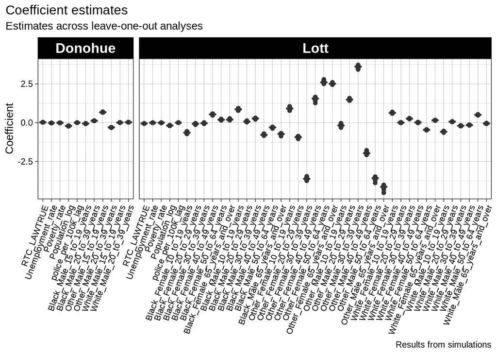

```r
simulations |>
  ggplot(aes(x = term, y = estimate)) +
  geom_boxplot() +
  facet_grid(. ~ Analysis, scale = "free_x", space = "free", drop = TRUE) +
  labs(title = "Coefficient estimates",
       subtitle = "Estimates across leave-one-out analyses",
       x = "Term",
       y = "Coefficient",
       caption = "Results from simulations") +
  theme_linedraw() +
  theme(axis.title.x = element_blank(),
        axis.text.x = element_text(angle = 70, hjust = 1),
        strip.text.x = element_text(size = 14, face = "bold"),
        plot.title.position="plot")
```

Next, we calculate the variance inflation factor to mathematically determine the collinearity:Donohue

```r
# model matrix
lm_DONOHUE_data <- as.data.frame(model.matrix(DONOHUE_OUTPUT))
# define model
lm_DONOHUE_data <- lm_DONOHUE_data |>
  mutate(Viol_crime_rate_1k_log = plm::Within(pull(
    d_panel_DONOHUE, Viol_crime_rate_1k_log
  )), effect = "twoways")
# specify model
lm_DONOHUE <- lm(Viol_crime_rate_1k_log ~
RTC_LAWTRUE +
  White_Male_15_to_19_years +
  White_Male_20_to_39_years +
  Black_Male_15_to_19_years +
  Black_Male_20_to_39_years +
  Other_Male_15_to_19_years +
  Other_Male_20_to_39_years +
  Unemployment_rate +
  Poverty_rate +
  Population_log +
  police_per_100k_lag,
data = lm_DONOHUE_data
)
# calculate VIF
vif_DONOHUE <- vif(lm_DONOHUE)
```

We table our gathered information:

```r
vif_DONOHUE <- vif_DONOHUE |>
  as_tibble() |>
  cbind(names(vif_DONOHUE)) |>
  as_tibble()
colnames(vif_DONOHUE) <- c("VIF", "Variable")
vif_DONOHUE |>
  arrange(desc(VIF))
```

```
## # A tibble: 11 × 2
##      VIF Variable
##    <dbl> <chr>
##  1  1.72 White_Male_20_to_39_years
##  2  1.66 Black_Male_20_to_39_years
##  3  1.58 Other_Male_15_to_19_years
##  4  1.52 Other_Male_20_to_39_years
##  5  1.34 Black_Male_15_to_19_years
##  6  1.27 Poverty_rate
##  7  1.23 Unemployment_rate
##  8  1.21 police_per_100k_lag
##  9  1.17 Population_log
## 10  1.15 White_Male_15_to_19_years
## 11  1.11 RTC_LAWTRUE
```

Now we do the same VIF analysis for Lott:

```r
lm_LOTT_data <- as.data.frame(model.matrix(LOTT_OUTPUT))
lm_LOTT_data <- lm_LOTT_data |>
  mutate(Viol_crime_rate_1k_log = plm::Within(pull(d_panel_LOTT, Viol_crime_rate_1k_log), effect = "twoways")) |>
  rename(RTC_LAW = RTC_LAWTRUE)
lm_LOTT <- lm(LOTT_fmla, data = lm_LOTT_data)
vif_LOTT <- vif(lm_LOTT)
vif_LOTT <- vif_LOTT |>
  as_tibble() |>
  cbind(names(vif_LOTT)) |>
  as_tibble()
colnames(vif_LOTT) <- c("VIF", "Variable")
```

We table our information for lott VIF:

```r
vif_LOTT |>
  mutate(Variable = str_replace(string = Variable,
                                pattern = "RTC_LAW",
                                replacement = "RTC_LAWTRUE")) |>
  arrange(desc(VIF))
```

```
## # A tibble: 41 × 2
##      VIF Variable
##    <dbl> <chr>
##  1  342. Black_Female_10_to_19_years
##  2  327. Black_Male_10_to_19_years
##  3  251. Other_Male_40_to_49_years
##  4  227. Other_Female_40_to_49_years
##  5  177. Other_Male_50_to_64_years
##  6  157. Other_Male_10_to_19_years
##  7  148. Other_Female_10_to_19_years
##  8  134. Other_Female_50_to_64_years
##  9  121. White_Female_10_to_19_years
## 10  120. White_Male_10_to_19_years
## # … with 31 more rows
```

Next, it’s time to compare the VIFs for Donohue and Lott and visualize it:

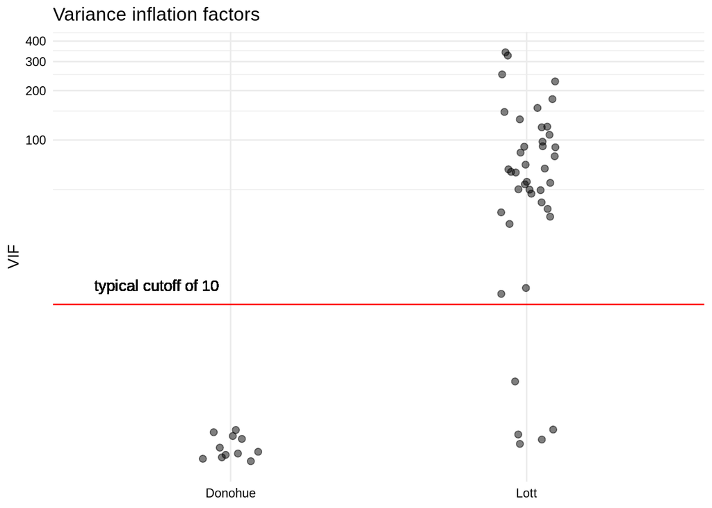

```r
vif_DONOHUE <- vif_DONOHUE |>
  mutate(Analysis = "Donohue")
vif_LOTT <- vif_LOTT |>
  mutate(Analysis = "Lott")
vif_df <- bind_rows(vif_DONOHUE, vif_LOTT)
vif_df |>
  ggplot(aes(x = Analysis, y = VIF)) +
  geom_jitter(width = 0.1, alpha = 0.5, size = 2) +
  geom_hline(yintercept = 10, color = "red") +
  geom_text(aes(.75, 13, label = "typical cutoff of 10")) +
  coord_trans(y = "log10") +
  labs(title = "Variance inflation factors") +
  theme_minimal() +
  theme(axis.title.x = element_blank(),
        axis.text.x = element_text(color = "black"),
        axis.text.y = element_text(color = "black"))
```

```r
DONOHUE_OUTPUT_p <- plm(police_per_100k_lag ~
                      RTC_LAW +
                      White_Male_15_to_19_years +
                      White_Male_20_to_39_years +
                      Black_Male_15_to_19_years +
                      Black_Male_20_to_39_years +
                      Other_Male_15_to_19_years +
                      Other_Male_20_to_39_years +
                      Unemployment_rate +
                      Poverty_rate +
                      Population_log +
                      Viol_crime_rate_1k_log,
                      effect = "twoways",
                      model = "within",
                      data = d_panel_DONOHUE)

DONOHUE_OUTPUT_p_TIDY <- tidy(DONOHUE_OUTPUT_p, conf.int = 0.95)
DONOHUE_OUTPUT_p_TIDY
```

```
## # A tibble: 11 × 7
##    term                      estimate std.e…¹ stati…²  p.value conf.low conf.h…³
##    <chr>                        <dbl>   <dbl>   <dbl>    <dbl>    <dbl>    <dbl>
##  1 RTC_LAWTRUE                  7.79    3.37    2.31  2.08e- 2    1.19   14.4
##  2 White_Male_15_to_19_years    0.797   5.60    0.142 8.87e- 1  -10.2    11.8
##  3 White_Male_20_to_39_years   12.5     1.97    6.34  3.18e-10    8.63   16.3
##  4 Black_Male_15_to_19_years  -65.3    11.3    -5.76  1.07e- 8  -87.5   -43.1
##  5 Black_Male_20_to_39_years   -5.34    3.93   -1.36  1.74e- 1  -13.0     2.36
##  6 Other_Male_15_to_19_years -105.     22.7    -4.60  4.54e- 6 -149.    -60.2
##  7 Other_Male_20_to_39_years   29.1     7.75    3.75  1.82e- 4   13.9    44.3
##  8 Unemployment_rate            2.69    0.991   2.72  6.69e- 3    0.750   4.64
##  9 Poverty_rate                -1.26    0.595  -2.12  3.46e- 2   -2.43   -0.0928
## 10 Population_log             -40.2    12.3    -3.27  1.09e- 3  -64.2   -16.1
## 11 Viol_crime_rate_1k_log      22.1     5.52    4.00  6.72e- 5   11.3    32.9
## # … with abbreviated variable names ¹std.error, ²statistic, ³conf.high
```

According to the model output, we can see a strong positive correlation between the number of law enforcement officers and violent crime rate.